# GIS III - Geostatistics in R

# Ordinary Kriging

```r
lzn.kriged = krige(log(zinc)~1, meuse, meuse.grid, model = lzn.vgm.fit)
```

```
## [using ordinary kriging]
```

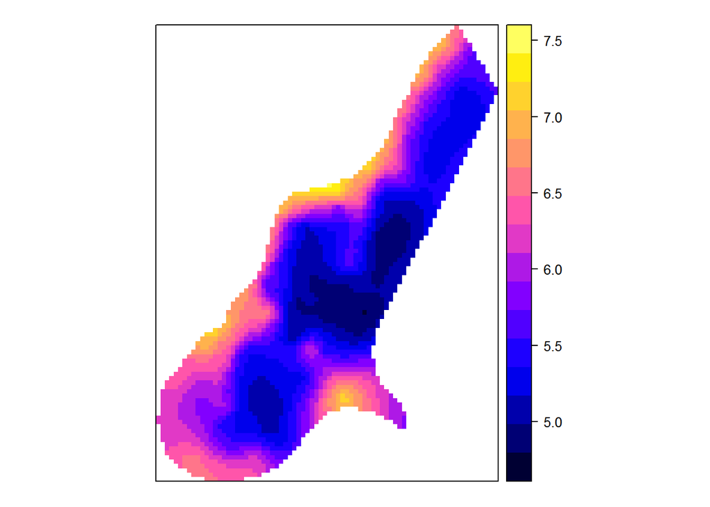

```r
# model -> contains the variogram model parameters and type
spplot(lzn.kriged,"var1.pred")
```

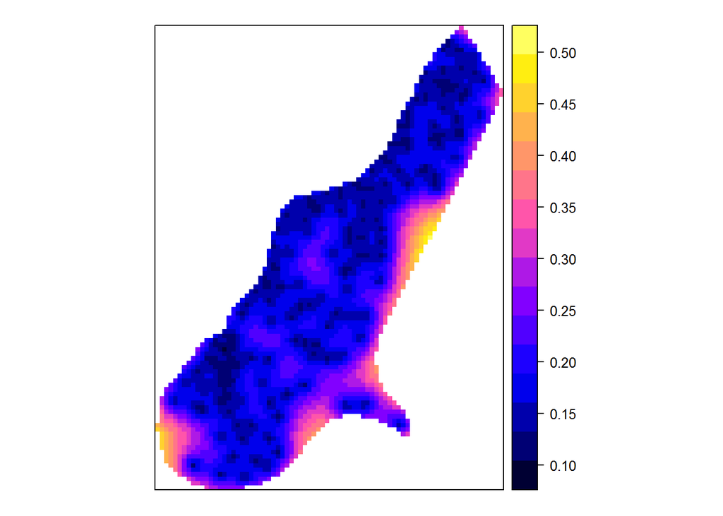

```r
# pred means predicted values
spplot(lzn.kriged,"var1.var")
```

```r
# var means variance values
```

# Ordinary Kriging with local neighborhoods

```r
lzn.kriged2 = krige(log(zinc)~1, meuse, meuse.grid, model = lzn.vgm.fit, nmax = 16, nmin = 4, maxdist = 500)
```

```
## [using ordinary kriging]
```

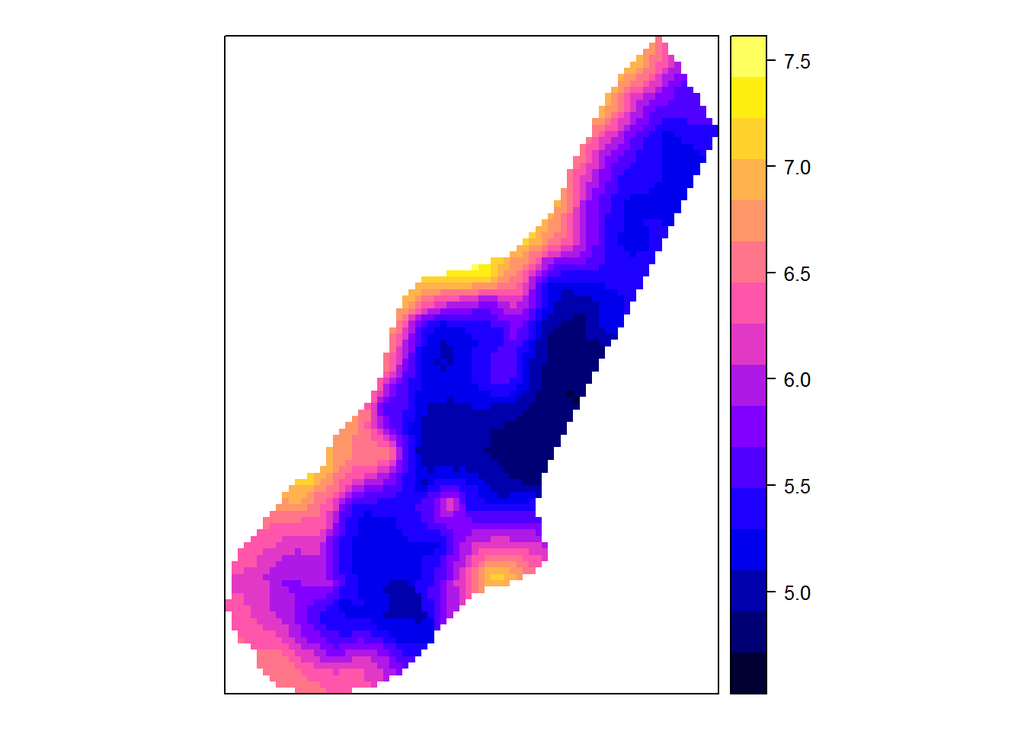

```r
spplot(lzn.kriged2,"var1.pred")
```

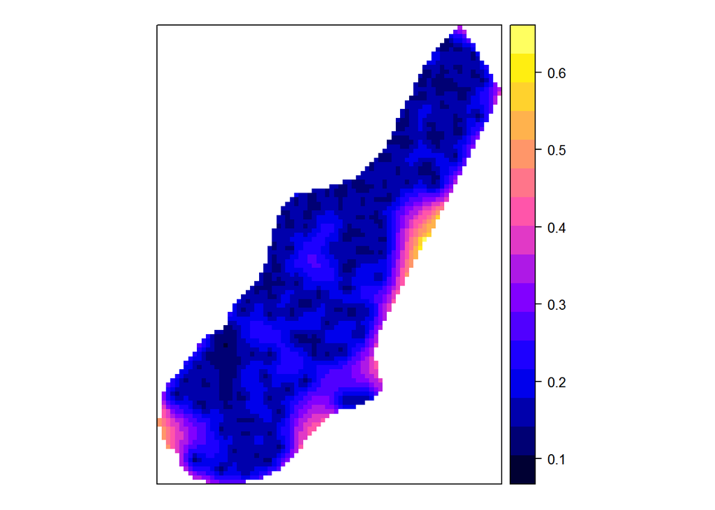

```r
# pred means predicted values
spplot(lzn.kriged2,"var1.var")
```

```r
# var means variance values
```

# Kriging with a Trend Model: Introduction

1. Estimate, using Generalized Least Squares (GLS), the coefficients of a linear model linking the known attribute values at the data locations with the co-located data on auxiliary variables
2. Use that model to predict the known attribute values at the sample data locations, and compute the corresponding residuals (from the regression model)
3. Compute the sample semivariogram of those residuals and fit parametric semivariogram model
4. Use the regression model to predict the unknown attribute values at any grid node where the corresponding data of the auxiliary variables are available
5. Predict, via Simple Kriging with known mean = 0, the residuals at the grid nodes
6. Add the regression-based and Simple-Kriging-derived predictions to compute the final predicted attribute values; this simple addition does not hold for the computation of the corresponing Kriging variance.

There are multiple variations on this general theme underline spatial prediction via Kriging:

- when the auxiliary variable is a vector of 1s, i.e., an intercept only model, and one is considering Kriging with moving local neighborhoods, the entire procedure is termed **Ordinary Kriging**
- when the auxiliary variables pertain to coordinates, the entire procedure is termed **Universal Kriging**
- in the general auxiliary variable case, the original **Kriging with External Drift** procedure assumes a linear multiple regression model, whereas recent variations allow for non-linear models under the term **Regression Kriging**. Note that the theoretical developments are more clear in the former case.

In what follows, you will first be establishing a linear regression model, using Ordinary Least Squares (OLS), between the log zinc concentrations and the square root of the distance to the river Meuse, using the followng R syntax:

> log(zinc) ~ sqrt(dist)

implies a linear regression model with log(zinc) being the dependent variable and sqrt(dist) being the explanatory variable. Note that the values of variable “dist” are already pre-computed and available as a separate column in the *meuse* data frame.